# House_Price (Regression)

## DATA DESCRIPTION

MSSubClassMSSubClass: Identifies the type of dwelling involved in the sale.

```
    20  1-STORY 1946 & NEWER ALL STYLES
    30  1-STORY 1945 & OLDER
    40  1-STORY W/FINISHED ATTIC ALL AGES
    45  1-1/2 STORY - UNFINISHED ALL AGES
    50  1-1/2 STORY FINISHED ALL AGES
    60  2-STORY 1946 & NEWER
    70  2-STORY 1945 & OLDER
    75  2-1/2 STORY ALL AGES
    80  SPLIT OR MULTI-LEVEL
    85  SPLIT FOYER
    90  DUPLEX - ALL STYLES AND AGES
   120  1-STORY PUD (Planned Unit Development) - 1946 & NEWER
   150  1-1/2 STORY PUD - ALL AGES
   160  2-STORY PUD - 1946 & NEWER
   180  PUD - MULTILEVEL - INCL SPLIT LEV/FOYER
   190  2 FAMILY CONVERSION - ALL STYLES AND AGES
```

MSZoning: Identifies the general zoning classification of the sale.

```
   A    Agriculture
   C    Commercial
   FV   Floating Village Residential
   I    Industrial
   RH   Residential High Density
   RL   Residential Low Density
   RP   Residential Low Density Park
   RM   Residential Medium Density
```

LotFrontage: Linear feet of street connected to property

LotArea: Lot size in square feet

Street: Type of road access to property

```
   Grvl Gravel
   Pave Paved
```

Alley: Type of alley access to property

```
   Grvl Gravel
   Pave Paved
   NA   No alley access
```

LotShape: General shape of property

```
   Reg  Regular
   IR1  Slightly irregular
   IR2  Moderately Irregular
   IR3  Irregular
```

LandContour: Flatness of the property

```
   Lvl  Near Flat/Level
   Bnk  Banked - Quick and significant rise from street grade to building
   HLS  Hillside - Significant slope from side to side
   Low  Depression
```

Utilities: Type of utilities available

```
   AllPub   All public Utilities (E,G,W,& S)
   NoSewr   Electricity, Gas, and Water (Septic Tank)
   NoSeWa   Electricity and Gas Only
   ELO  Electricity only
```

LotConfig: Lot configuration

```
   Inside   Inside lot
   Corner   Corner lot
   CulDSac  Cul-de-sac
   FR2  Frontage on 2 sides of property
   FR3  Frontage on 3 sides of property
```

LandSlope: Slope of property

```
   Gtl  Gentle slope
   Mod  Moderate Slope
   Sev  Severe Slope
```

Neighborhood: Physical locations within Ames city limits

```
   Blmngtn  Bloomington Heights
   Blueste  Bluestem
   BrDale   Briardale
   BrkSide  Brookside
   ClearCr  Clear Creek
   CollgCr  College Creek
   Crawfor  Crawford
   Edwards  Edwards
   Gilbert  Gilbert
   IDOTRR   Iowa DOT and Rail Road
   MeadowV  Meadow Village
   Mitchel  Mitchell
   Names    North Ames
   NoRidge  Northridge
   NPkVill  Northpark Villa
   NridgHt  Northridge Heights
   NWAmes   Northwest Ames
   OldTown  Old Town
   SWISU    South & West of Iowa State University
   Sawyer   Sawyer
   SawyerW  Sawyer West
   Somerst  Somerset
   StoneBr  Stone Brook
   Timber   Timberland
   Veenker  Veenker
```

Condition1: Proximity to various conditions

```
   Artery   Adjacent to arterial street
   Feedr    Adjacent to feeder street
   Norm Normal
   RRNn Within 200' of North-South Railroad
   RRAn Adjacent to North-South Railroad
   PosN Near positive off-site feature--park, greenbelt, etc.
   PosA Adjacent to postive off-site feature
   RRNe Within 200' of East-West Railroad
   RRAe Adjacent to East-West Railroad
```

Condition2: Proximity to various conditions (if more than one is present)

```
   Artery   Adjacent to arterial street
   Feedr    Adjacent to feeder street
   Norm Normal
   RRNn Within 200' of North-South Railroad
   RRAn Adjacent to North-South Railroad
   PosN Near positive off-site feature--park, greenbelt, etc.
   PosA Adjacent to postive off-site feature
   RRNe Within 200' of East-West Railroad
   RRAe Adjacent to East-West Railroad
```

BldgType: Type of dwelling

```
   1Fam Single-family Detached
   2FmCon   Two-family Conversion; originally built as one-family dwelling
   Duplx    Duplex
   TwnhsE   Townhouse End Unit
   TwnhsI   Townhouse Inside Unit
```

HouseStyle: Style of dwelling

```
   1Story   One story
   1.5Fin   One and one-half story: 2nd level finished
   1.5Unf   One and one-half story: 2nd level unfinished
   2Story   Two story
   2.5Fin   Two and one-half story: 2nd level finished
   2.5Unf   Two and one-half story: 2nd level unfinished
   SFoyer   Split Foyer
   SLvl Split Level
```

OverallQual: Rates the overall material and finish of the house

```
   10   Very Excellent
   9    Excellent
   8    Very Good
   7    Good
   6    Above Average
   5    Average
   4    Below Average
   3    Fair
   2    Poor
   1    Very Poor
```

OverallCond: Rates the overall condition of the house

```
   10   Very Excellent
   9    Excellent
   8    Very Good
   7    Good
   6    Above Average
   5    Average
   4    Below Average
   3    Fair
   2    Poor
   1    Very Poor
```

YearBuilt: Original construction date

YearRemodAdd: Remodel date (same as construction date if no remodeling or additions)

RoofStyle: Type of roof

```
   Flat Flat
   Gable    Gable
   Gambrel  Gabrel (Barn)
   Hip  Hip
   Mansard  Mansard
   Shed Shed
```

RoofMatl: Roof material

```
   ClyTile  Clay or Tile
   CompShg  Standard (Composite) Shingle
   Membran  Membrane
   Metal    Metal
   Roll Roll
   Tar&Grv  Gravel & Tar
   WdShake  Wood Shakes
   WdShngl  Wood Shingles
```

Exterior1st: Exterior covering on house

```
   AsbShng  Asbestos Shingles
   AsphShn  Asphalt Shingles
   BrkComm  Brick Common
   BrkFace  Brick Face
   CBlock   Cinder Block
   CemntBd  Cement Board
   HdBoard  Hard Board
   ImStucc  Imitation Stucco
   MetalSd  Metal Siding
   Other    Other
   Plywood  Plywood
   PreCast  PreCast
   Stone    Stone
   Stucco   Stucco
   VinylSd  Vinyl Siding
   Wd Sdng  Wood Siding
   WdShing  Wood Shingles
```

Exterior2nd: Exterior covering on house (if more than one material)

```
   AsbShng  Asbestos Shingles
   AsphShn  Asphalt Shingles
   BrkComm  Brick Common
   BrkFace  Brick Face
   CBlock   Cinder Block
   CemntBd  Cement Board
   HdBoard  Hard Board
   ImStucc  Imitation Stucco
   MetalSd  Metal Siding
   Other    Other
   Plywood  Plywood
   PreCast  PreCast
   Stone    Stone
   Stucco   Stucco
   VinylSd  Vinyl Siding
   Wd Sdng  Wood Siding
   WdShing  Wood Shingles
```

MasVnrType: Masonry veneer type

```
   BrkCmn   Brick Common
   BrkFace  Brick Face
   CBlock   Cinder Block
   None None
   Stone    Stone
```

MasVnrArea: Masonry veneer area in square feet

ExterQual: Evaluates the quality of the material on the exterior

```
   Ex   Excellent
   Gd   Good
   TA   Average/Typical
   Fa   Fair
   Po   Poor
```

ExterCond: Evaluates the present condition of the material on the exterior

```
   Ex   Excellent
   Gd   Good
   TA   Average/Typical
   Fa   Fair
   Po   Poor
```

Foundation: Type of foundation

```
   BrkTil   Brick & Tile
   CBlock   Cinder Block
   PConc    Poured Contrete
   Slab Slab
   Stone    Stone
   Wood Wood
```

BsmtQual: Evaluates the height of the basement

```
   Ex   Excellent (100+ inches)
   Gd   Good (90-99 inches)
   TA   Typical (80-89 inches)
   Fa   Fair (70-79 inches)
   Po   Poor (<70 inches
   NA   No Basement
```

BsmtCond: Evaluates the general condition of the basement

```
   Ex   Excellent
   Gd   Good
   TA   Typical - slight dampness allowed
   Fa   Fair - dampness or some cracking or settling
   Po   Poor - Severe cracking, settling, or wetness
   NA   No Basement
```

BsmtExposure: Refers to walkout or garden level walls

```
   Gd   Good Exposure
   Av   Average Exposure (split levels or foyers typically score average or above)
   Mn   Mimimum Exposure
   No   No Exposure
   NA   No Basement
```

BsmtFinType1: Rating of basement finished area

```
   GLQ  Good Living Quarters
   ALQ  Average Living Quarters
   BLQ  Below Average Living Quarters
   Rec  Average Rec Room
   LwQ  Low Quality
   Unf  Unfinshed
   NA   No Basement
```

BsmtFinSF1: Type 1 finished square feet

BsmtFinType2: Rating of basement finished area (if multiple types)

```
   GLQ  Good Living Quarters
   ALQ  Average Living Quarters
   BLQ  Below Average Living Quarters
   Rec  Average Rec Room
   LwQ  Low Quality
   Unf  Unfinshed
   NA   No Basement
```

BsmtFinSF2: Type 2 finished square feet

BsmtUnfSF: Unfinished square feet of basement area

TotalBsmtSF: Total square feet of basement area

Heating: Type of heating

```
   Floor    Floor Furnace
   GasA Gas forced warm air furnace
   GasW Gas hot water or steam heat
   Grav Gravity furnace
   OthW Hot water or steam heat other than gas
   Wall Wall furnace
```

HeatingQC: Heating quality and condition

```
   Ex   Excellent
   Gd   Good
   TA   Average/Typical
   Fa   Fair
   Po   Poor
```

CentralAir: Central air conditioning

```
   N    No
   Y    Yes
```

Electrical: Electrical system

```
   SBrkr    Standard Circuit Breakers & Romex
   FuseA    Fuse Box over 60 AMP and all Romex wiring (Average)
   FuseF    60 AMP Fuse Box and mostly Romex wiring (Fair)
   FuseP    60 AMP Fuse Box and mostly knob & tube wiring (poor)
   Mix  Mixed
```

1stFlrSF: First Floor square feet

2ndFlrSF: Second floor square feet

LowQualFinSF: Low quality finished square feet (all floors)

GrLivArea: Above grade (ground) living area square feet

BsmtFullBath: Basement full bathrooms

BsmtHalfBath: Basement half bathrooms

FullBath: Full bathrooms above grade

HalfBath: Half baths above grade

Bedroom: Bedrooms above grade (does NOT include basement bedrooms)

Kitchen: Kitchens above grade

KitchenQual: Kitchen quality

```
   Ex   Excellent
   Gd   Good
   TA   Typical/Average
   Fa   Fair
   Po   Poor
```

TotRmsAbvGrd: Total rooms above grade (does not include bathrooms)

Functional: Home functionality (Assume typical unless deductions are warranted)

```
   Typ  Typical Functionality
   Min1 Minor Deductions 1
   Min2 Minor Deductions 2
   Mod  Moderate Deductions
   Maj1 Major Deductions 1
   Maj2 Major Deductions 2
   Sev  Severely Damaged
   Sal  Salvage only
```

Fireplaces: Number of fireplaces

FireplaceQu: Fireplace quality

```
   Ex   Excellent - Exceptional Masonry Fireplace
   Gd   Good - Masonry Fireplace in main level
   TA   Average - Prefabricated Fireplace in main living area or Masonry Fireplace in basement
   Fa   Fair - Prefabricated Fireplace in basement
   Po   Poor - Ben Franklin Stove
   NA   No Fireplace
```

GarageType: Garage location

```
   2Types   More than one type of garage
   Attchd   Attached to home
   Basment  Basement Garage
   BuiltIn  Built-In (Garage part of house - typically has room above garage)
   CarPort  Car Port
   Detchd   Detached from home
   NA   No Garage
```

GarageYrBlt: Year garage was built

GarageFinish: Interior finish of the garage

```
   Fin  Finished
   RFn  Rough Finished
   Unf  Unfinished
   NA   No Garage
```

GarageCars: Size of garage in car capacity

GarageArea: Size of garage in square feet

GarageQual: Garage quality

```
   Ex   Excellent
   Gd   Good
   TA   Typical/Average
   Fa   Fair
   Po   Poor
   NA   No Garage
```

GarageCond: Garage condition

```
   Ex   Excellent
   Gd   Good
   TA   Typical/Average
   Fa   Fair
   Po   Poor
   NA   No Garage
```

PavedDrive: Paved driveway

```
   Y    Paved
   P    Partial Pavement
   N    Dirt/Gravel
```

WoodDeckSF: Wood deck area in square feet

OpenPorchSF: Open porch area in square feet

EnclosedPorch: Enclosed porch area in square feet

3SsnPorch: Three season porch area in square feet

ScreenPorch: Screen porch area in square feet

PoolArea: Pool area in square feet

PoolQC: Pool quality

```
   Ex   Excellent
   Gd   Good
   TA   Average/Typical
   Fa   Fair
   NA   No Pool
```

Fence: Fence quality

```
   GdPrv    Good Privacy
   MnPrv    Minimum Privacy
   GdWo Good Wood
   MnWw Minimum Wood/Wire
   NA   No Fence
```

MiscFeature: Miscellaneous feature not covered in other categories

```
   Elev Elevator
   Gar2 2nd Garage (if not described in garage section)
   Othr Other
   Shed Shed (over 100 SF)
   TenC Tennis Court
   NA   None
```

MiscVal: $Value of miscellaneous feature

MoSold: Month Sold (MM)

YrSold: Year Sold (YYYY)

SaleType: Type of sale

```
   WD   Warranty Deed - Conventional
   CWD  Warranty Deed - Cash
   VWD  Warranty Deed - VA Loan
   New  Home just constructed and sold
   COD  Court Officer Deed/Estate
   Con  Contract 15% Down payment regular terms
   ConLw    Contract Low Down payment and low interest
   ConLI    Contract Low Interest
   ConLD    Contract Low Down
   Oth  Other
```

SaleCondition: Condition of sale

```
   Normal   Normal Sale
   Abnorml  Abnormal Sale -  trade, foreclosure, short sale
   AdjLand  Adjoining Land Purchase
   Alloca   Allocation - two linked properties with separate deeds, typically condo with a garage unit
   Family   Sale between family members
   Partial  Home was not completed when last assessed (associated with New Homes)
```

```python
# Importing required Libraries
import pandas as pd
import matplotlib.pyplot as plt
import seaborn as sb
```

```python
from warnings import filterwarnings
filterwarnings("ignore")
```

#### Import training and testing dataset

```python
train = pd.read_csv('C:/Work/DATA_SCI-ANA/Datasets/Housing/training_set.csv')
test = pd.read_csv('C:/Work/DATA_SCI-ANA/Datasets/Housing/testing_set.csv')
```

```python
train.head()
```

|  | Id | MSSubClass | MSZoning | LotFrontage | LotArea | Street | Alley | LotShape | LandContour | Utilities | ... | PoolArea | PoolQC | Fence | MiscFeature | MiscVal | MoSold | YrSold | SaleType | SaleCondition | SalePrice |
| --- | --- | --- | --- | --- | --- | --- | --- | --- | --- | --- | --- | --- | --- | --- | --- | --- | --- | --- | --- | --- | --- |
| 0 | 1 | 60 | RL | 65.0 | 8450 | Pave | NaN | Reg | Lvl | AllPub | ... | 0 | NaN | NaN | NaN | 0 | 2 | 2008 | WD | Normal | 208500 |
| 1 | 2 | 20 | RL | 80.0 | 9600 | Pave | NaN | Reg | Lvl | AllPub | ... | 0 | NaN | NaN | NaN | 0 | 5 | 2007 | WD | Normal | 181500 |
| 2 | 3 | 60 | RL | 68.0 | 11250 | Pave | NaN | IR1 | Lvl | AllPub | ... | 0 | NaN | NaN | NaN | 0 | 9 | 2008 | WD | Normal | 223500 |
| 3 | 4 | 70 | RL | 60.0 | 9550 | Pave | NaN | IR1 | Lvl | AllPub | ... | 0 | NaN | NaN | NaN | 0 | 2 | 2006 | WD | Abnorml | 140000 |
| 4 | 5 | 60 | RL | 84.0 | 14260 | Pave | NaN | IR1 | Lvl | AllPub | ... | 0 | NaN | NaN | NaN | 0 | 12 | 2008 | WD | Normal | 250000 |

5 rows × 81 columns

#### As given in data description above, data contains many values which are no applicable to particular column. Hence to avoid conflicts between null values and not applicable values, we will substitute 'No [columnname]' for not applicable values.

```python
train.Alley = train.Alley.fillna("No alley access")
train.BsmtQual = train.BsmtQual.fillna("No Basement")
train.BsmtCond = train.BsmtCond.fillna("No Basement")
train.BsmtExposure = train.BsmtExposure.fillna("No Basement")
train.BsmtFinType1 = train.BsmtFinType1.fillna("No Basement")
train.BsmtFinType2 = train.BsmtFinType2.fillna("No Basement")
train.FireplaceQu = train.FireplaceQu.fillna("No Fireplace")
train.GarageType = train.GarageType.fillna("No Garage")
train.GarageFinish = train.GarageFinish.fillna("No Garage")
train.GarageQual = train.GarageQual.fillna("No Garage")
train.GarageCond = train.GarageCond.fillna("No Garage")
train.PoolQC = train.PoolQC.fillna("No Pool")
train.Fence = train.Fence.fillna("No Fence")
train.MiscFeature = train.MiscFeature.fillna("None")
```

```python
test.Alley = test.Alley.fillna("No alley access")
test.BsmtQual = test.BsmtQual.fillna("No Basement")
test.BsmtCond = test.BsmtCond.fillna("No Basement")
test.BsmtExposure = test.BsmtExposure.fillna("No Basement")
test.BsmtFinType1 = test.BsmtFinType1.fillna("No Basement")
test.BsmtFinType2 = test.BsmtFinType2.fillna("No Basement")
test.FireplaceQu = test.FireplaceQu.fillna("No Fireplace")
test.GarageType = test.GarageType.fillna("No Garage")
test.GarageFinish = test.GarageFinish.fillna("No Garage")
test.GarageQual = test.GarageQual.fillna("No Garage")
test.GarageCond = test.GarageCond.fillna("No Garage")
test.PoolQC = test.PoolQC.fillna("No Pool")
test.Fence = test.Fence.fillna("No Fence")
test.MiscFeature = test.MiscFeature.fillna("None")
```

```python
train.isna().sum()
```

```
Id                 0
MSSubClass         0
MSZoning           0
LotFrontage      259
LotArea            0
                ...
MoSold             0
YrSold             0
SaleType           0
SaleCondition      0
SalePrice          0
Length: 81, dtype: int64
```

#### Exploratory Data Analysis (EDA)

#### 1.Treating missing values

```python
for i in train.columns:
    if (train[i].dtypes == 'object'):
        x = train[i].mode()[0]
        train[i] =train[i].fillna(x)
    else:
        x = train[i].mean()
        train[i] = train[i].fillna(x)
```

```python
train.isna().sum()
```

```
Id               0
MSSubClass       0
MSZoning         0
LotFrontage      0
LotArea          0
                ..
MoSold           0
YrSold           0
SaleType         0
SaleCondition    0
SalePrice        0
Length: 81, dtype: int64
```

#### 2. Differentiating data on basis of data type

```python
cat = []
con = []


for i in train.columns:
    if (train[i].dtypes == 'object'):
        cat.append(i)
    else:
        con.append(i)
```

```python
#categorical columns
cat
```

```
['MSZoning',
 'Street',
 'Alley',
 'LotShape',
 'LandContour',
 'Utilities',
 'LotConfig',
 'LandSlope',
 'Neighborhood',
 'Condition1',
 'Condition2',
 'BldgType',
 'HouseStyle',
 'RoofStyle',
 'RoofMatl',
 'Exterior1st',
 'Exterior2nd',
 'MasVnrType',
 'ExterQual',
 'ExterCond',
 'Foundation',
 'BsmtQual',
 'BsmtCond',
 'BsmtExposure',
 'BsmtFinType1',
 'BsmtFinType2',
 'Heating',
 'HeatingQC',
 'CentralAir',
 'Electrical',
 'KitchenQual',
 'Functional',
 'FireplaceQu',
 'GarageType',
 'GarageFinish',
 'GarageQual',
 'GarageCond',
 'PavedDrive',
 'PoolQC',
 'Fence',
 'MiscFeature',
 'SaleType',
 'SaleCondition']
```

```python
#continuous columns
con
```

```
['Id',
 'MSSubClass',
 'LotFrontage',
 'LotArea',
 'OverallQual',
 'OverallCond',
 'YearBuilt',
 'YearRemodAdd',
 'MasVnrArea',
 'BsmtFinSF1',
 'BsmtFinSF2',
 'BsmtUnfSF',
 'TotalBsmtSF',
 '1stFlrSF',
 '2ndFlrSF',
 'LowQualFinSF',
 'GrLivArea',
 'BsmtFullBath',
 'BsmtHalfBath',
 'FullBath',
 'HalfBath',
 'BedroomAbvGr',
 'KitchenAbvGr',
 'TotRmsAbvGrd',
 'Fireplaces',
 'GarageYrBlt',
 'GarageCars',
 'GarageArea',
 'WoodDeckSF',
 'OpenPorchSF',
 'EnclosedPorch',
 '3SsnPorch',
 'ScreenPorch',
 'PoolArea',
 'MiscVal',
 'MoSold',
 'YrSold',
 'SalePrice']
```

```python
conti = train[con]
cate = train[cat]
```

```python
conti.skew()
```

```
Id                0.000000
MSSubClass        1.407657
LotFrontage       2.384950
LotArea          12.207688
OverallQual       0.216944
OverallCond       0.693067
YearBuilt        -0.613461
YearRemodAdd     -0.503562
MasVnrArea        2.676412
BsmtFinSF1        1.685503
BsmtFinSF2        4.255261
BsmtUnfSF         0.920268
TotalBsmtSF       1.524255
1stFlrSF          1.376757
2ndFlrSF          0.813030
LowQualFinSF      9.011341
GrLivArea         1.366560
BsmtFullBath      0.596067
BsmtHalfBath      4.103403
FullBath          0.036562
HalfBath          0.675897
BedroomAbvGr      0.211790
KitchenAbvGr      4.488397
TotRmsAbvGrd      0.676341
Fireplaces        0.649565
GarageYrBlt      -0.668175
GarageCars       -0.342549
GarageArea        0.179981
WoodDeckSF        1.541376
OpenPorchSF       2.364342
EnclosedPorch     3.089872
3SsnPorch        10.304342
ScreenPorch       4.122214
PoolArea         14.828374
MiscVal          24.476794
MoSold            0.212053
YrSold            0.096269
SalePrice         1.882876
dtype: float64
```

```python
from sklearn.preprocessing import PowerTransformer
pt = PowerTransformer()
conti = pt.fit_transform(conti)
conti = pd.DataFrame(conti, columns = con)
```

```python
conti.skew()
```

```
Id               -0.285760
MSSubClass        0.069019
LotFrontage       0.173047
LotArea           0.026569
OverallQual       0.018233
OverallCond       0.032376
YearBuilt        -0.134920
YearRemodAdd     -0.225561
MasVnrArea        0.405245
BsmtFinSF1       -0.411401
BsmtFinSF2        2.425650
BsmtUnfSF        -0.274971
TotalBsmtSF       0.232534
1stFlrSF         -0.001106
2ndFlrSF          0.280724
LowQualFinSF      7.299413
GrLivArea         0.000171
BsmtFullBath      0.360390
BsmtHalfBath      3.859402
FullBath         -0.049435
HalfBath          0.521435
BedroomAbvGr      0.123625
KitchenAbvGr     -2.800950
TotRmsAbvGrd      0.001879
Fireplaces        0.083549
GarageYrBlt      -0.133723
GarageCars       -0.024840
GarageArea       -0.328235
WoodDeckSF        0.132275
OpenPorchSF      -0.014772
EnclosedPorch     2.047941
3SsnPorch         7.613746
ScreenPorch       3.113266
PoolArea         14.352680
MiscVal           5.016528
MoSold           -0.039399
YrSold            0.093295
SalePrice        -0.008654
dtype: float64
```

```python
conti.corr()[['SalePrice']]
```

|  | SalePrice |
| --- | --- |
| Id | -0.016745 |
| MSSubClass | -0.010626 |
| LotFrontage | 0.350233 |
| LotArea | 0.398997 |
| OverallQual | 0.813658 |
| OverallCond | -0.006262 |
| YearBuilt | 0.619622 |
| YearRemodAdd | 0.561854 |
| MasVnrArea | 0.406061 |
| BsmtFinSF1 | 0.249904 |
| BsmtFinSF2 | -0.032713 |
| BsmtUnfSF | 0.212549 |
| TotalBsmtSF | 0.610857 |
| 1stFlrSF | 0.606967 |
| 2ndFlrSF | 0.170097 |
| LowQualFinSF | -0.057153 |
| GrLivArea | 0.729386 |
| BsmtFullBath | 0.239029 |
| BsmtHalfBath | -0.002985 |
| FullBath | 0.592144 |
| HalfBath | 0.326973 |
| BedroomAbvGr | 0.211827 |
| KitchenAbvGr | -0.119356 |
| TotRmsAbvGrd | 0.538916 |
| Fireplaces | 0.511624 |
| GarageYrBlt | 0.538360 |
| GarageCars | 0.683774 |
| GarageArea | 0.647222 |
| WoodDeckSF | 0.339803 |
| OpenPorchSF | 0.458870 |
| EnclosedPorch | -0.217981 |
| 3SsnPorch | 0.058397 |
| ScreenPorch | 0.100107 |
| PoolArea | 0.068392 |
| MiscVal | -0.073563 |
| MoSold | 0.056987 |
| YrSold | -0.037884 |
| SalePrice | 1.000000 |

```python
conti = conti.drop(labels = ['Id','MSSubClass','LotFrontage','LotArea','OverallCond','MasVnrArea','BsmtFinSF1','BsmtFinSF2','BsmtUnfSF','2ndFlrSF','LowQualFinSF','BsmtFullBath','HalfBath','BedroomAbvGr','KitchenAbvGr','Fireplaces','GarageYrBlt','WoodDeckSF','OpenPorchSF','EnclosedPorch','3SsnPorch','ScreenPorch','PoolArea','MiscVal','MoSold','YrSold','SalePrice'],axis=1)
```

#### Dropping columns with P-Value greater than 0.05 from categorical section

```python
from scipy.stats import chi2_contingency
for i in cate[cat]:
    Q = pd.crosstab(train.SalePrice,train[i])
    a,b,c,d = chi2_contingency(Q)
    print(i,b[(b<0.05)])
```

```
MSZoning [4.34832506e-11]
Street [8.33887038e-09]
Alley []
LotShape [4.72472916e-12]
LandContour []
Utilities []
LotConfig [0.04580621]
LandSlope []
Neighborhood [1.3649601e-08]
Condition1 []
Condition2 []
BldgType []
HouseStyle []
RoofStyle []
RoofMatl []
Exterior1st []
Exterior2nd []
MasVnrType [1.59752358e-06]
ExterQual [4.25028917e-34]
ExterCond [9.86979031e-13]
Foundation [9.664522e-06]
BsmtQual [1.19186987e-29]
BsmtCond [4.71040939e-21]
BsmtExposure [3.49573077e-14]
BsmtFinType1 []
BsmtFinType2 []
Heating [2.4777533e-24]
HeatingQC []
CentralAir [1.22571267e-05]
Electrical []
KitchenQual [1.2820745e-31]
Functional []
FireplaceQu [4.38772329e-08]
GarageType []
GarageFinish [2.12937569e-10]
GarageQual []
GarageCond []
PavedDrive []
PoolQC []
Fence []
MiscFeature []
SaleType [4.56078539e-14]
SaleCondition [5.61339568e-14]
```

```python
cate = cate.drop(labels = ['Alley','LandContour','Utilities','LandSlope','Condition1','Condition2','BldgType','HouseStyle','RoofStyle','RoofMatl','Exterior1st','Exterior2nd','BsmtFinType1','BsmtFinType2','HeatingQC','Electrical','Functional','GarageType','GarageQual','GarageCond','PavedDrive','PoolQC','Fence','MiscFeature'],axis = 1)
```

```python
cate
```

|  | MSZoning | Street | LotShape | LotConfig | Neighborhood | MasVnrType | ExterQual | ExterCond | Foundation | BsmtQual | BsmtCond | BsmtExposure | Heating | CentralAir | KitchenQual | FireplaceQu | GarageFinish | SaleType | SaleCondition |
| --- | --- | --- | --- | --- | --- | --- | --- | --- | --- | --- | --- | --- | --- | --- | --- | --- | --- | --- | --- |
| 0 | RL | Pave | Reg | Inside | CollgCr | BrkFace | Gd | TA | PConc | Gd | TA | No | GasA | Y | Gd | No Fireplace | RFn | WD | Normal |
| 1 | RL | Pave | Reg | FR2 | Veenker | None | TA | TA | CBlock | Gd | TA | Gd | GasA | Y | TA | TA | RFn | WD | Normal |
| 2 | RL | Pave | IR1 | Inside | CollgCr | BrkFace | Gd | TA | PConc | Gd | TA | Mn | GasA | Y | Gd | TA | RFn | WD | Normal |
| 3 | RL | Pave | IR1 | Corner | Crawfor | None | TA | TA | BrkTil | TA | Gd | No | GasA | Y | Gd | Gd | Unf | WD | Abnorml |
| 4 | RL | Pave | IR1 | FR2 | NoRidge | BrkFace | Gd | TA | PConc | Gd | TA | Av | GasA | Y | Gd | TA | RFn | WD | Normal |
| ... | ... | ... | ... | ... | ... | ... | ... | ... | ... | ... | ... | ... | ... | ... | ... | ... | ... | ... | ... |
| 1455 | RL | Pave | Reg | Inside | Gilbert | None | TA | TA | PConc | Gd | TA | No | GasA | Y | TA | TA | RFn | WD | Normal |
| 1456 | RL | Pave | Reg | Inside | NWAmes | Stone | TA | TA | CBlock | Gd | TA | No | GasA | Y | TA | TA | Unf | WD | Normal |
| 1457 | RL | Pave | Reg | Inside | Crawfor | None | Ex | Gd | Stone | TA | Gd | No | GasA | Y | Gd | Gd | RFn | WD | Normal |
| 1458 | RL | Pave | Reg | Inside | NAmes | None | TA | TA | CBlock | TA | TA | Mn | GasA | Y | Gd | No Fireplace | Unf | WD | Normal |
| 1459 | RL | Pave | Reg | Inside | Edwards | None | Gd | TA | CBlock | TA | TA | No | GasA | Y | TA | No Fireplace | Fin | WD | Normal |

1460 rows × 19 columns

#### One Hot Encoding Categorical Columns

```python
cate = pd.get_dummies(cate)
```

```python
df = conti.join(cate)
```

#### Setting X and Y variables

```python
X = df
Y = train[['SalePrice']]
```

#### Splitting the dataset for training and testing

```python
from sklearn.model_selection import train_test_split
xtrain,xtest,ytrain,ytest = train_test_split(X,Y,random_state= 21,test_size= 0.2)
```

#### Model 1) Linear Regression

```python
from sklearn.linear_model import LinearRegression
lr = LinearRegression()
#model
model = lr.fit(xtrain,ytrain)
#prediction
pred_tr = model.predict(xtrain)
pred_ts = model.predict(xtest)
#Error
from sklearn.metrics import mean_squared_error
tr_err = mean_squared_error(ytrain,pred_tr)
ts_err = mean_squared_error(ytest,pred_ts)
```

```python
tr_err
```

```
839684330.9075342
```

```python
ts_err
```

```
1210389889.0753424
```

- we can try to reduce overfitting either by Lasso or Ridge regression
- But errors are huge its better to switch to different model

#### Model 2) Decision Tree Regressor

```python
tr = []
ts = []
for i in range(2,20,1):
    from sklearn.tree import DecisionTreeRegressor
    dtr = DecisionTreeRegressor(random_state=21,max_depth=i,min_samples_leaf=i,min_samples_split=i)

    model = dtr.fit(xtrain,ytrain)
    pred_tr = model.predict(xtrain)
    pred_ts = model.predict(xtest)

    #training error
    from sklearn.metrics import r2_score
    tr_err = r2_score(ytrain,pred_tr)
    tr.append(tr_err)

    #testing error
    ts_err = mean_squared_error(ytest,pred_ts)


    ts.append(ts_err)
```

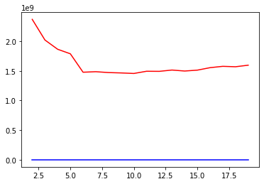

```python
    import matplotlib.pyplot as plt
    plt.plot(range(2,20,1),tr,c="blue")
    plt.plot(range(2,20,1),ts,c="red")
```

#### Model 3) Random Forest Regressor

```python
from sklearn.model_selection import GridSearchCV
from sklearn.ensemble import RandomForestRegressor
from sklearn.metrics import mean_absolute_error,mean_squared_error
```

```python
param_grid = {
    'n_estimators': [200, 500],
    'max_depth' : [4,5,6,7,8],
    'criterion' :['mse', 'mae']
}
```

```python
rfr = RandomForestRegressor()
CV_rfr = GridSearchCV(estimator=rfr, param_grid=param_grid)
CV_rfr.fit(xtrain, ytrain)
```

```
GridSearchCV(estimator=RandomForestRegressor(),
             param_grid={'criterion': ['mse', 'mae'],
                         'max_depth': [4, 5, 6, 7, 8],
                         'n_estimators': [200, 500]})
```

```python
CV_rfr.best_params_
```

```
{'criterion': 'mse', 'max_depth': 8, 'n_estimators': 500}
```

```python
rfr = RandomForestRegressor(criterion= 'mse',max_depth= 8, n_estimators = 200)
model = rfr.fit(xtrain, ytrain)
pred_tr = model.predict(xtrain)
pred_ts = model.predict(xtest)
```

```python
tr_score = r2_score(ytrain,pred_tr)
ts_score = r2_score(ytest,pred_ts)
```

```python
tr_score
```

```
0.9594929670437073
```

```python
ts_score
```

```
0.8183966189143481
```

#### Model 3] Adaboost classifier (Boosting Approach)

```python
from sklearn.ensemble import AdaBoostClassifier
```

```python
param_grid = {
    'n_estimators': [10, 50,100,200,500],
    'learning_rate': [0.0001,0.001,0.01,0.1,1.0],
    'algorithm' : ['SAMME','SAMME.R']
}
```

```python
abc = AdaBoostClassifier()
CV_abc = GridSearchCV(estimator=abc, param_grid=param_grid, cv= 10,scoring='explained_variance')
```

```python
CV_abc.fit(xtrain,ytrain)
```

```
GridSearchCV(cv=10, estimator=AdaBoostClassifier(),
             param_grid={'algorithm': ['SAMME', 'SAMME.R'],
                         'learning_rate': [0.0001, 0.001, 0.01, 0.1, 1.0],
                         'n_estimators': [10, 50, 100, 200, 500]},
             scoring='explained_variance')
```

```python
CV_abc.best_params_
```

```
{'algorithm': 'SAMME.R', 'learning_rate': 0.001, 'n_estimators': 500}
```

```python
CV_abc.best_score_
```

```
0.4542551428164985
```

#### Model 4] Logistic Regression

```python
param_grid = {
    'solver': ['llfgs','sag','saga','newton-cg','liblinear'],
        'C' :[0.1,0.2,0.3,0.4,0.5],
   'penalty':['l1','l2','elasticnet']
}
```

```python
from sklearn.linear_model import LogisticRegression
lr = LogisticRegression()
CV_lr = GridSearchCV(estimator=lr, param_grid=param_grid)
CV_lr.fit(xtrain, ytrain)
```

```
GridSearchCV(estimator=LogisticRegression(),
             param_grid={'C': [0.1, 0.2, 0.3, 0.4, 0.5],
                         'penalty': ['l1', 'l2', 'elasticnet'],
                         'solver': ['llfgs', 'sag', 'saga', 'newton-cg',
                                    'liblinear']})
```

```python
CV_lr.best_params_
```

```
{'C': 0.1, 'penalty': 'l2', 'solver': 'saga'}
```

```python
CV_lr.best_score_
```

```
0.022262572906349733
```

```python
from sklearn.linear_model import LogisticRegression
lr = LogisticRegression(solver='saga',C= 0.1)
model = lr.fit(xtrain,ytrain)
```

```python
pred_tr = model.predict(xtrain)
pred_ts = model.predict(xtest)
```

```python
print((r2_score(ytrain,pred_tr)))
print((r2_score(ytest,pred_ts)))
```

```
0.6255996710713856
0.5545833316245106
```

#### Making test set ready for prediction

```python
test
```

|  | Id | MSSubClass | MSZoning | LotFrontage | LotArea | Street | Alley | LotShape | LandContour | Utilities | ... | ScreenPorch | PoolArea | PoolQC | Fence | MiscFeature | MiscVal | MoSold | YrSold | SaleType | SaleCondition |
| --- | --- | --- | --- | --- | --- | --- | --- | --- | --- | --- | --- | --- | --- | --- | --- | --- | --- | --- | --- | --- | --- |
| 0 | 1461 | 20 | RH | 80.0 | 11622 | Pave | No alley access | Reg | Lvl | AllPub | ... | 120 | 0 | No Pool | MnPrv | None | 0 | 6 | 2010 | WD | Normal |
| 1 | 1462 | 20 | RL | 81.0 | 14267 | Pave | No alley access | IR1 | Lvl | AllPub | ... | 0 | 0 | No Pool | No Fence | Gar2 | 12500 | 6 | 2010 | WD | Normal |
| 2 | 1463 | 60 | RL | 74.0 | 13830 | Pave | No alley access | IR1 | Lvl | AllPub | ... | 0 | 0 | No Pool | MnPrv | None | 0 | 3 | 2010 | WD | Normal |
| 3 | 1464 | 60 | RL | 78.0 | 9978 | Pave | No alley access | IR1 | Lvl | AllPub | ... | 0 | 0 | No Pool | No Fence | None | 0 | 6 | 2010 | WD | Normal |
| 4 | 1465 | 120 | RL | 43.0 | 5005 | Pave | No alley access | IR1 | HLS | AllPub | ... | 144 | 0 | No Pool | No Fence | None | 0 | 1 | 2010 | WD | Normal |
| ... | ... | ... | ... | ... | ... | ... | ... | ... | ... | ... | ... | ... | ... | ... | ... | ... | ... | ... | ... | ... | ... |
| 1454 | 2915 | 160 | RM | 21.0 | 1936 | Pave | No alley access | Reg | Lvl | AllPub | ... | 0 | 0 | No Pool | No Fence | None | 0 | 6 | 2006 | WD | Normal |
| 1455 | 2916 | 160 | RM | 21.0 | 1894 | Pave | No alley access | Reg | Lvl | AllPub | ... | 0 | 0 | No Pool | No Fence | None | 0 | 4 | 2006 | WD | Abnorml |
| 1456 | 2917 | 20 | RL | 160.0 | 20000 | Pave | No alley access | Reg | Lvl | AllPub | ... | 0 | 0 | No Pool | No Fence | None | 0 | 9 | 2006 | WD | Abnorml |
| 1457 | 2918 | 85 | RL | 62.0 | 10441 | Pave | No alley access | Reg | Lvl | AllPub | ... | 0 | 0 | No Pool | MnPrv | Shed | 700 | 7 | 2006 | WD | Normal |
| 1458 | 2919 | 60 | RL | 74.0 | 9627 | Pave | No alley access | Reg | Lvl | AllPub | ... | 0 | 0 | No Pool | No Fence | None | 0 | 11 | 2006 | WD | Normal |

1459 rows × 80 columns

```python
for i in test.columns:
    if (test[i].dtypes == 'object'):
        x = test[i].mode()[0]
        test[i] =test[i].fillna(x)
    else:
        x = test[i].mean()
        test[i] = test[i].fillna(x)
```